# Notebook

[Sebastian Raschka](http://sebastianraschka.com)  
last updated: 06/02/2014

- [Open in IPython nbviewer](http://nbviewer.ipython.org/github/rasbt/One-Python-benchmark-per-day/blob/master/ipython_nbs/day5_flattening_lists.ipynb?create=1)
- [Link to this IPython notebook on Github](https://github.com/rasbt/One-Python-benchmark-per-day/blob/master/ipython_nbs/day5_flattening_lists.ipynb)
- [Link to the GitHub Repository One-Python-benchmark-per-day](https://github.com/rasbt/One-Python-benchmark-per-day)

I would be happy to hear your comments and suggestions.  
Please feel free to drop me a note via [twitter](https://twitter.com/rasbt), , or [google+](https://plus.google.com/118404394130788869227).

# Day 5 - One Python Benchmark per Day

## Comparing 9 ways of flattening a list of sublists

**-> skip to the results**

Here, we are only looking of ways to flatten 2D-lists, i.e., lists of sublists. Flattening of lists with more than 2 dimensions will be tested separately.  
The desired behavior of the different approaches shall be:

```
[[1],[2,3,4],[5],[6]]    ->   [1, 2, 3, 4, 5, 6]
[[1],[2,[3],4],[5],[6]]  ->   [1, 2, [3], 4, 5, 6]
```

# Code implementations

### Classic approaches

```python
def append_in_for_loop(list_2d):
    flattened = []
    for sublist in list_2d:
        for item in sublist:
                flattened.append(item)
    return flattened
```

```python
def extend_in_for_loop(list_2d):
    flattened = []
    for sublist in list_2d:
        flattened.extend(sublist)
    return flattened
```

```python
def list_comprehension(list_2d):
    return [item for sublist in list_2d for item in sublist]
```

```python
def flatten_via_sum(list_2d):
    return sum(list_2d, [])
```

### `itertools` approaches

```python
import itertools
```

```python
def itertools_chain_from_iterable(list_2d):
    return list(itertools.chain.from_iterable(list_2d))
```

```python
def itertools_chain(list_2d):
    return list(itertools.chain(*list_2d))
```

### `functools` approaches

```python
import functools
import operator
```

```python
def functools_reduce_lambda(list_2d):
    return functools.reduce(lambda x,y: x+y, list_2d)
```

```python
def functools_reduce_operator(list_2d):
    return functools.reduce(operator.add, map(list, list_2d))
```

```python
def functools_reduce_list_add(list_2d):
    return functools.reduce(list.__add__, (list(sub) for sub in list_2d))
```

## Assertion tests

```python
funcs = [
     append_in_for_loop, list_comprehension, flatten_via_sum,
     itertools_chain_from_iterable, itertools_chain,
     functools_reduce_lambda, extend_in_for_loop,
     functools_reduce_operator, functools_reduce_list_add
    ]
```

```python
for f in funcs:
    assert (f([[1],[2,3,4],[5],[6]]) == [1, 2, 3, 4, 5, 6]),\
    '%s failed test 1'% f.__name__
    assert (f([[1],[2,[3],4],[5],[6]]) == [1, 2, [3], 4, 5, 6]),\
    '%s failed test 2'% f.__name__
print('ok')
```

```
ok
```

## Timing

```python
import timeit
import random
import copy
import numpy as np
random.seed(12345)

def make_copy(l):
    return copy.deepcopy(l)

func_names = [f.__name__ for f in funcs]

orders_n = [10**n for n in range(1, 5)]
timings = {f:[] for f in func_names}

for n in orders_n:
    l = [[i for i in range(random.randint(1,10))] for j in range(n)]
    for f in func_names:
        timings[f].append(min(timeit.Timer('%s(make_copy(l))' %f,
                      'from __main__ import %s, l, make_copy' %f)
                              .repeat(repeat=3, number=10)))
```

## Plotting

```python
%matplotlib inline
```

```python
import platform
import multiprocessing

def print_sysinfo():

    print('\nPython version  :', platform.python_version())
    print('compiler        :', platform.python_compiler())

    print('\nsystem     :', platform.system())
    print('release    :', platform.release())
    print('machine    :', platform.machine())
    print('processor  :', platform.processor())
    print('CPU count  :', multiprocessing.cpu_count())
    print('interpreter:', platform.architecture()[0])
    print('\n\n')
```

```python
import matplotlib.pyplot as plt

def plot():
    labels_fast = {'append_in_for_loop':'.append() in for-loop',
          'extend_in_for_loop':'.extend() in for-loop',
          'list_comprehension': 'List comprehension',
          'itertools_chain_from_iterable': 'list(itertools.chain.from_iterable(list_2d))',
          'itertools_chain': 'list(itertools.chain(*list_2d))',
          }
    labels_slow = {'functools_reduce_lambda': 'functools.reduce(lambda x,y: x+y, list_2d)',
              'functools_reduce_operator': 'functools.reduce(operator.add, map(list, list_2d))',
              'flatten_via_sum': 'sum(list_2d, [])',
              'functools_reduce_list_add': 'functools.reduce(list.__add__, (list(sub) for sub in list_2d))'
              }
    plt.rcParams.update({'font.size': 9})
    fig = plt.figure(figsize=(10,8))
    plt.title('Performance of different methods for flattening a list of sublists', fontsize=18)

    reds = ['#F87217', '#F75D59', '#FF0000', '#C24641']
    for lb,col in zip(sorted(labels_slow.keys()), reds):
        plt.plot(orders_n, [t**2 for t in timings[lb]], alpha=0.3, label=labels_slow[lb],
                 marker='o', lw=2, c=col, markersize=8)

    blues = ['#000080', '#2B60DE', '#736AFF', '#659EC7', '#46C7C7']
    for lb,col in zip(sorted(labels_fast.keys()), blues):
        plt.plot(orders_n, [t**2 for t in timings[lb]], alpha=0.3, label=labels_fast[lb],
                 marker='^', lw=2, c=col, markersize=10)
    max_perf = max( s/c for s,c in zip(timings['flatten_via_sum'],
                                   timings['list_comprehension']) )
    ftext = 'A list comprehension \n  >>[item for sublist '\
        'in list_2d for item in sublist]\n'\
        'is {:.2f}x faster for flattening a 2D list than \n  >>sum(list_2d, [])\nat n = 10000'\
        .format(max_perf)
    plt.figtext(.4,.15, ftext, fontsize=13, ha='left')

    plt.legend(loc='upper left')
    plt.grid()
    plt.ylabel('Time per computation for 10 loops (in seconds)', fontsize=12)
    plt.xlabel('Number of sublists', fontsize=12)
    plt.xscale('log')
    plt.yscale('log')
    plt.show()
```

# Results

```
Python version  : 3.4.0
compiler        : GCC 4.2.1 (Apple Inc. build 5577)

system     : Darwin
release    : 13.2.0
machine    : x86_64
processor  : i386
CPU count  : 4
interpreter: 64bit
```

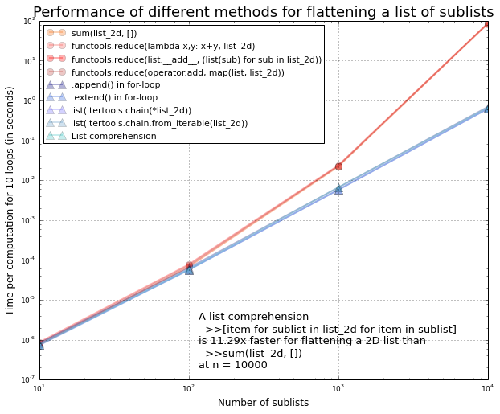

```python
print_sysinfo()
plot()
```

## Conclusion

Of course, the `sum(list_2d, [])` has a very short syntax and might be just convenient to use it for list flattening, but the reason why it is so slow is that it will create a new "intermediate" list for every element (Note that all operations in that are shown in red shades in the plot above follow this same principle).  
I would like to suggest to you the nice article ["How Not to Flatten a List of Lists in Python"](http://mathieularose.com/how-not-to-flatten-a-list-of-lists-in-python/) by Mathieu Larose, who described this mechanism very nicely.

## Bonus - Which of the methods is actually the fastest?

```python
import timeit
import random
import copy
import numpy as np
random.seed(12345)

def make_copy(l):
    return copy.deepcopy(l)

labels_fast = {
          'append_in_for_loop':'.append() in for-loop',
          'extend_in_for_loop':'.extend() in for-loop',
          'list_comprehension': 'List comprehension',
          'itertools_chain_from_iterable': 'list(itertools.chain.from_iterable(list_2d))',
          'itertools_chain': 'list(itertools.chain(*list_2d))',
          }

fast_names = [f for f in labels_fast.keys()]
fast_times = []

l = [[i for i in range(random.randint(1,10))] for j in range(10**5)]
for f in fast_names:
    fast_times.append(min(timeit.Timer('%s(make_copy(l))' %f,
        'from __main__ import %s, l, make_copy' %f)
                    .repeat(repeat=3, number=10)))
```

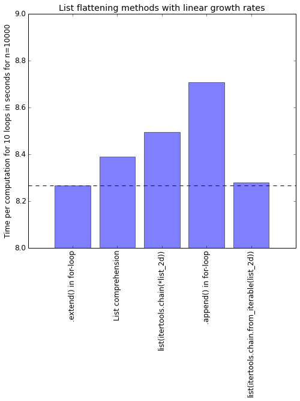

```python
plt.rcParams.update({'font.size': 12})

fast_labels = [labels_fast[l] for l in fast_names]
x_pos = np.arange(len(fast_labels))

plt.figure(figsize=(8,7))
plt.bar(x_pos, fast_times, align='center', alpha=0.5)
plt.xticks(x_pos, fast_labels, rotation=90)
plt.axhline(y=min(fast_times), linestyle='--', color='black')
plt.ylabel('Time per computation for 10 loops in seconds for n=10000')
plt.title('List flattening methods with linear growth rates')
plt.ylim(8,9)
plt.show()
```